# 第13講 時系列解析

モデルの推定と予測

Published

January 9, 2026

## 準備

以下で利用する共通パッケージを読み込む．

```r
library(conflicted) # 関数名の衝突を警告
  conflicts_prefer(   # 優先的に使う関数を指定
    dplyr::filter(),
    dplyr::lag(),
    dplyr::select(),
    scales::discard(),
    recipes::fixed(),
    yardstick::spec(),
    recipes::step(),
    ggtime::gg_tsresiduals(),
    ggtime::gg_tsdisplay(),
    )
library(tidyverse)
library(ggfortify)
library(ggrepel)
library(GGally)
library(gt)
library(gtsummary)
library(fable)
library(tsibble)
library(feasts)
library(ggtime)
library(urca)
library(patchwork)
#' macOSのための日本語表示の設定
if(Sys.info()["sysname"] == "Darwin") { # macOSか調べる
    jp_font <- "HiraMaruProN-W4"
    theme_update(text = element_text(family = jp_font))
    update_geom_defaults("text", list(family = theme_get()$text$family))
    update_geom_defaults("label", list(family = theme_get()$text$family))
    update_geom_defaults("text_repel", list(family = theme_get()$text$family))
    update_geom_defaults("label_repel", list(family = theme_get()$text$family))
} else {jp_font <- NULL}
```

## 自己相関

自己相関・共分散に関連する関数を再掲する．

**Note**

```r
ACF(.data,  y, ...,  lag_max = NULL,
    type = c("correlation", "covariance", "partial"),
    na.action = na.contiguous, demean = TRUE, tapered = FALSE)
#' .data: 時系列データ (tsibbleクラス)
#' y: 計算対象の列名
#' type: 標準は相関, 共分散と偏相関を選ぶこともできる
#' na.action: 欠損値の処理，標準は欠損を含むと計算しない
#' demean: 共分散の計算において平均を引くか否か
#' 詳細は '?feasts::ACF' を参照
```

関数 `ACF()`の返値を関数 `autoplot()` に渡せば 適切なグラフを描画することができる．

```r
toy_acf <- arima.sim(model = list(ar = c(0.8, -0.64),
                                  ma = c(-0.5)),
                     n = 200) |>
    as_tsibble() |> ACF(value)
toy_acf |> autoplot()
```

### 問題

以下の問に答えなさい．

- 同じAR過程のモデルから生成した時系列の自己相関を比較しなさい．(前回の練習問題を利用すればよい)
- MA過程についても同様な比較を行いなさい．
- ARMA過程についても同様な比較を行いなさい．

### 解答例

前回作成した自作の関数 `my_arma()` を利用しても良いが， 今回は関数 `stats::arima.sim()` を用いた方法を紹介する．

```r
Tmax <- 500 # 時系列の長さ t=1,..,Tmax
K <- 4 # 表示する時系列の数 (4つを並べて比較する)
ts_ar <- ts(replicate(K, arima.sim(list(ar = c(0.67, 0.26)),
                                   n = Tmax)))
ts_ma <- ts(replicate(K, arima.sim(list(ma = c(0.44, -0.28)),
                                   n = Tmax)))
ts_arma <- ts(replicate(K, arima.sim(list(ar = c(0.8, -0.64),
                                          ma = c(-0.5)),
                                     n = Tmax)))
```

AR(2)モデルの自己相関を計算する．

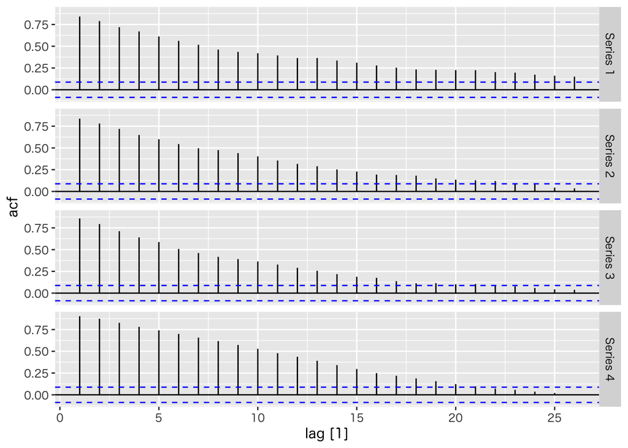

```r
ts_ar |> as_tsibble() |> ACF(value) |> autoplot()
```

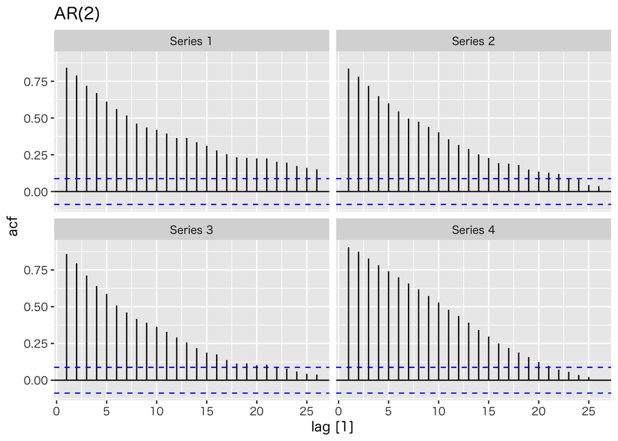

```r
ts_ar |> as_tsibble() |> ACF(value) |>
    autoplot() + # 格子状に並べるには facet を指定する
    facet_wrap(key ~ .) + # 適宜調整してくれる
    labs(title = "AR(2)")
```

MA(2)モデルの自己相関を計算する．

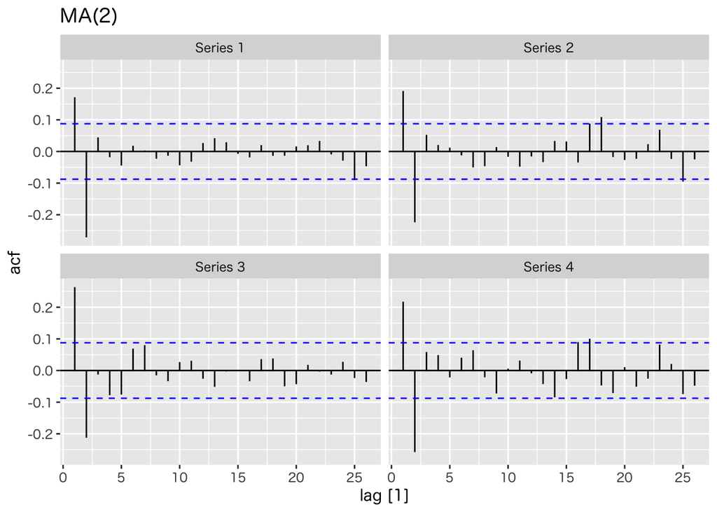

```r
ts_ma |> as_tsibble() |> ACF(value) |>
    autoplot() +
    facet_wrap(key ~ .) +
    labs(title = "MA(2)")
```

ARMA(2,1)モデルの自己相関を計算する．

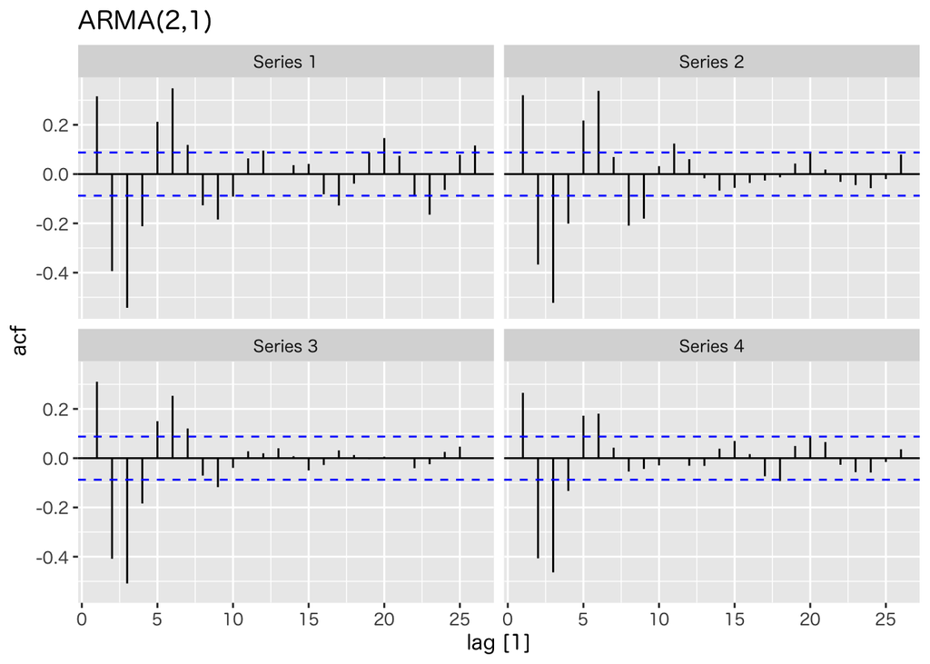

```r
ts_arma |> as_tsibble() |> ACF(value) |>
    autoplot() +
    facet_wrap(key ~ .) +
    labs(title = "ARMA(2,1)")
```

同じホワイトノイズでAR,MA,ARMAを生成するには以下のようにすればよい．

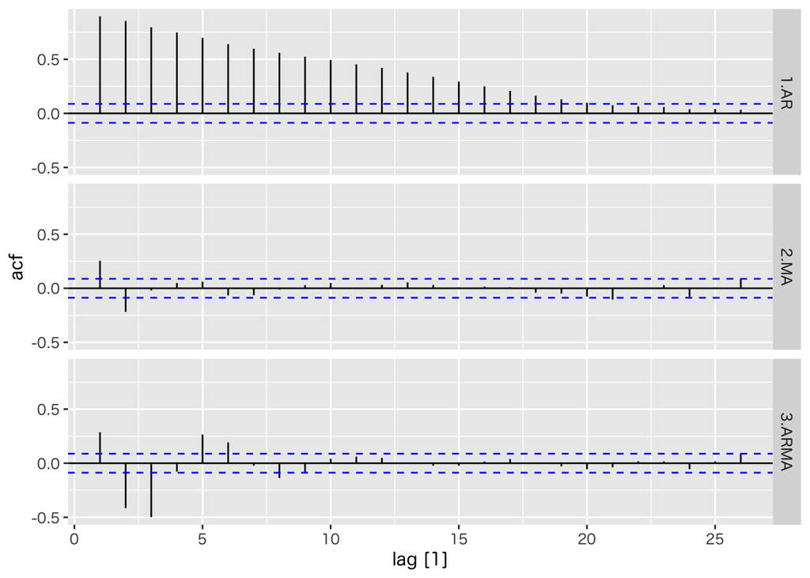

```r
epsilon <- rnorm(Tmax)
toy_ar <- arima.sim(list(ar = c(0.67, 0.26)),
                    n = Tmax,
                    innov = epsilon)
toy_ma <- arima.sim(list(ma = c(0.44, -0.28)),
                    n = Tmax,
                    innov = epsilon)
toy_arma <- arima.sim(list(ar = c(0.8, -0.64),
                           ma = c(-0.5)),
                      n = Tmax,
                      innov = epsilon)
ts(bind_cols(`1.AR`=toy_ar, `2.MA`=toy_ma, `3.ARMA`=toy_arma)) |>
    as_tsibble() |> ACF(value) |> autoplot()
```

なお，`facet` はそのままだとアルファベット順に並べられるので， ここでは簡単に番号を付けて回避している．

## AR/ARMAモデルの推定

モデルの推定には モデルを指定して関数 `fabletools::model()` を用いる．

**Noteモデルの推定**

```r
model(.data, ...)
#' .data: 時系列データ (tsibbleクラス)
#' ...: モデルを指定
#' 詳細は `?fabletools::model` を参照
```

ARモデルの指定には以下の関数を用いる．

```r
AR(formula, ic = c("aicc", "aic", "bic"), ...)
#' formula: 時系列モデル
#' ic: モデル選択のための情報量規準
#' 詳細は `?fable::AR` を参照
```

ARMAモデルの指定には以下の関数を用いる．

```r
ARIMA(formula, ic = c("aicc", "aic", "bic"),
      stepwise = TRUE, greedy = TRUE, approximation = NULL, ...)
#' formula: 時系列モデル
#' ic: モデル選択のための情報量規準
#' stepwise/greedy/approximation: モデル探索のための設定
#' 詳細は '?fable::ARIMA' を参照
```

関数 `AR()`, `ARMA()` ともに， モデル式を指定しない場合には 既定値では情報量規準の一つであるAICc(修正AIC)を用いて次数が自動的に決定される．

典型的には以下のような使い方をする．

```r
toy_ar <- arima.sim(model = list(ar = c(0.7,-0.6, 0.5)),
                    n = 1000) |> as_tsibble()
toy_ar |> model(AR(value))                    # モデルを自動選択する場合
toy_ar |> model(AR(value ~ order(3)))         # モデルの次数を指定する場合
toy_ar |> model(AR(value ~ 0 + order(3)))     # 平均項を含めない場合
```

```r
toy_arima <- arima.sim(model = list(order = c(2,1,2),
                                    ar = c(0.8,-0.5),
                                    ma = c(-0.2,0.2)),
                       n = 1000) |> as_tsibble()
toy_arima |> model(ARIMA(value))                  # 自動選択
toy_arima |> model(ARIMA(value ~ 0 + pdq(2,1,2))) # 次数を指定
```

推定されたモデルから情報を取得するための補助的な関数には以下のものがある．

**Noteモデルの情報**

```r
report(object, ...)
#' object: 推定された時系列モデル
#' 詳細は `?fabletools::report` を参照
```

**Note係数の取得**

```r
tidy(object, ...)
#' object: 推定された時系列モデル
#' 詳細は '?fabletools::tidy.mdl_df' を参照
```

関数 `coef()` も同様の働きをする．

**Noteあてはめ値・残差の取得**

```r
augment(object, ...)
#' object: 推定された時系列モデル
#' 詳細は '?fabletools::augment.mdl_df' を参照
```

あてはめ値は関数 `fitted()/fitted.values()` で， 残差は関数 `residuals()/resid()` でも取得することが可能である．

モデルを評価するために以下の関数が用意されている．

**Note精度評価の取得**

```r
accuracy(object, ...)
#' object: 推定された時系列モデル
#' 詳細は '?fabletools::accuracy.mdl_df' を参照
```

**Note情報量規準などの取得**

```r
glance(object, ...)
#' object: 推定された時系列モデル
#' 詳細は '?fabletools::glance.mdl_df' を参照
```

**Note残差の視覚化**

```r
gg_tsresiduals(data, type = "innovation", ...)
#' data: 推定された時系列モデル
#' 詳細は `?ggtimes::gg_tsresiduals` を参照
```

描画には関数 `ggtime::gg_tsdisplay()` が利用される

具体的な使い方は以下のようになる．

```r
toy_fit <- toy_arima |> model(ARIMA(value))
toy_fit |> accuracy()
toy_fit |> glance()
toy_fit |> gg_tsresiduals()
```

### 問題

以下の問に答えなさい．

- AR過程を生成し，関数 `fable::AR()` を用いて係数を推定しなさい．
- ARMA過程を生成し，関数 `fable::ARIMA()` を用いて係数を推定しなさい．
- 推定結果の妥当性を残差の自己相関係数を調べることによって確認しなさい．

### 解答例

AR(2)過程に従うデータを生成する．

```r
toy_ar <- arima.sim(model = list(ar = c(0.67, 0.26)),
                    n = 5000) |> # 時系列の長さも自由に変更せよ
    as_tsibble()
```

関数 `fabletools::model()` `+` `fable::AR()` を用いて推定を行う．

```r
toy_ar_fit <- # 自動的に推定されたモデルを保存
    toy_ar |> model(AR(value))
toy_ar_fit |> report()   # 推定されたモデル
```

```
Series: value
Model: AR(2)

Coefficients:
     ar1     ar2
  0.6518  0.2687

sigma^2 estimated as 1.003
AIC = -8259.53  AICc = -8259.53 BIC = -8246.5
```

```r
toy_ar_fit |> tidy()     # 推定された係数とその評価
```

```
# A tibble: 2 × 6
  .model    term  estimate std.error statistic  p.value
  <chr>     <chr>    <dbl>     <dbl>     <dbl>    <dbl>
1 AR(value) ar1      0.652    0.0136      47.8 0
2 AR(value) ar2      0.269    0.0136      19.7 2.00e-83
```

```r
toy_ar_fit |> accuracy() # 推定されたモデルのあてはまりの評価
```

```
# A tibble: 1 × 10
  .model    .type          ME  RMSE   MAE   MPE  MAPE  MASE RMSSE     ACF1
  <chr>     <chr>       <dbl> <dbl> <dbl> <dbl> <dbl> <dbl> <dbl>    <dbl>
1 AR(value) Training -0.00879  1.00 0.800 -32.2  228. 0.938 0.937 -0.00562
```

```r
toy_ar_fit |> glance()   # 推定されたモデルの情報量規準など
```

```
# A tibble: 1 × 6
  .model    sigma2    AIC   AICc    BIC   dof
  <chr>      <dbl>  <dbl>  <dbl>  <dbl> <int>
1 AR(value)   1.00 -8260. -8260. -8247.  4998
```

ある程度長い系列であれば良い推定が得られる． `n = 1000` などとして推定結果がどのように変わるか試してみよ．

ARMA(2,1)過程に従うデータを生成する．

```r
toy_arma <- arima.sim(model = list(ar = c(0.67, 0.26), ma = c(-0.5)),
                      n = 2000) |>
    as_tsibble()
```

関数 `fabletools::model()` `+` `fable::ARIMA()` を用いて推定を行う．

```r
toy_arma_fit <- # 自動的に推定されたモデルを保存
    toy_arma |> model(
                    model0 = ARIMA(value ~ pdq(2,0,1)), # 正しいモデル
                    model1 = ARIMA(value ~ pdq(3,0,1)), # 間違ったモデル
                    model2 = ARIMA(value ~ pdq(2,0,2)), # 間違ったモデル
                    auto0  = ARIMA(value ~ pdq(d = 0)), # ARMAで自動推定(階差を取らない)
                    auto1  = ARIMA(value), # ARIMA全体で自動推定(モデルとしてはかなり冗長)
                    )
toy_arma_fit                             # 推定されたモデルの表示
```

```
# A mable: 1 x 5
          model0         model1         model2          auto0          auto1
         <model>        <model>        <model>        <model>        <model>
1 <ARIMA(2,0,1)> <ARIMA(3,0,1)> <ARIMA(2,0,2)> <ARIMA(2,0,1)> <ARIMA(1,1,1)>
```

```r
toy_arma_fit |> glance()                 # 推定されたモデルの評価
```

```
# A tibble: 5 × 8
  .model sigma2 log_lik   AIC  AICc   BIC ar_roots  ma_roots
  <chr>   <dbl>   <dbl> <dbl> <dbl> <dbl> <list>    <list>
1 model0   1.02  -2855. 5718. 5718. 5741. <cpl [2]> <cpl [1]>
2 model1   1.02  -2855. 5720. 5720. 5748. <cpl [3]> <cpl [1]>
3 model2   1.02  -2855. 5720. 5720. 5748. <cpl [2]> <cpl [2]>
4 auto0    1.02  -2855. 5718. 5718. 5741. <cpl [2]> <cpl [1]>
5 auto1    1.04  -2879. 5763. 5763. 5780. <cpl [1]> <cpl [1]>
```

```r
toy_arma_fit |> glance() |> arrange(AIC) # AIC順に並べる
```

```
# A tibble: 5 × 8
  .model sigma2 log_lik   AIC  AICc   BIC ar_roots  ma_roots
  <chr>   <dbl>   <dbl> <dbl> <dbl> <dbl> <list>    <list>
1 model0   1.02  -2855. 5718. 5718. 5741. <cpl [2]> <cpl [1]>
2 auto0    1.02  -2855. 5718. 5718. 5741. <cpl [2]> <cpl [1]>
3 model2   1.02  -2855. 5720. 5720. 5748. <cpl [2]> <cpl [2]>
4 model1   1.02  -2855. 5720. 5720. 5748. <cpl [3]> <cpl [1]>
5 auto1    1.04  -2879. 5763. 5763. 5780. <cpl [1]> <cpl [1]>
```

対数尤度 (`log_lik`) は大きい方が観測データへのあてはまりは良い． `AIC` は小さい方が良い予測となることが期待される． 自動推定では必ずしも正しいモデルが推定される訳ではないことに注意する． 特に短い時系列では推定が難しい場合が多い． 生成する系列の長さを変えて実験してみよ．

残差を評価する．

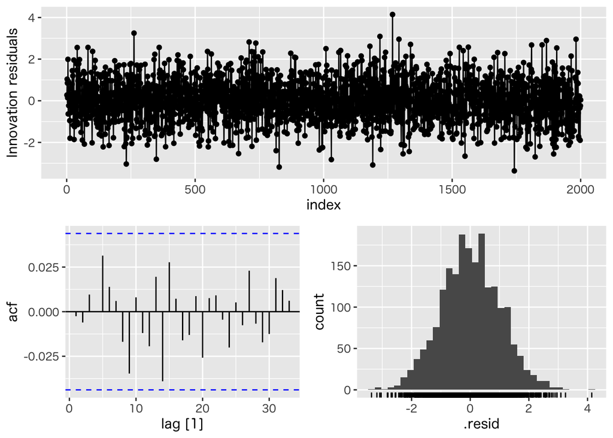

```r
toy_arma_fit |> select(model0) |> # 正しいモデル
    gg_tsresiduals()
```

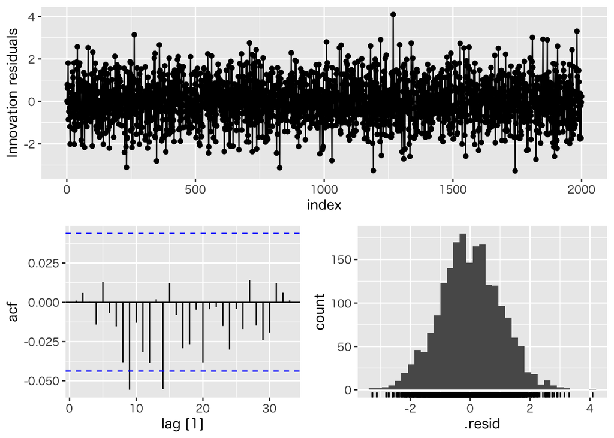

```r
toy_arma_fit |> select(auto1) |>  # 自動推定されたARMAモデル
    gg_tsresiduals()
```

残差は無相関になっていることが確認できる．

## 東京の気温の時系列モデル

時系列クラスを作成し，必要な部分列を切り出す方法を紹介する．

**Note時系列の作成(再掲)**

```r
tsibble(..., key = NULL, index, regular = TRUE, .drop = TRUE)
#' ...: データ
#' key: indexの補助情報(同じ時間の異なるデータを表す)
#' index: 時間情報を表す列を設定
#' 詳細は '?tsibble::tsibble' を参照
```

`ts` クラスや `tibble` クラスを `tsibble` クラスに変換するには以下を用いる．

```r
as_tsibble(x, key = NULL, index,
           regular = TRUE, validate = TRUE, .drop = TRUE, ...)
#' x: データ(時系列オブジェクトやデータフレーム)
#' 詳細は '?tsibble::as_tsibble' を参照
```

典型的な使い方は以下のようになる．

```r
tsibble(date = as_date("2024-01-01") + 0:9,
        value = rnorm(10))
tibble(year = 2001:2020,
       value = rnorm(20)) |>
    as_tsibble(index = year)  # yearを時間情報に指定
AirPassengers |> as_tsibble() # 時系列オブジェクトの変換
```

部分列の切り出しは関数 `filter()` の時系列版を利用する．

**Note部分列の切り出し**

```r
filter_index(.data, ..., .preserve = FALSE)
#' .data: tsibbleオブジェクト
#' ...: 区間を表す式 (~ end, start ~ end, start ~ .)
#' 詳細は `?tsibble::filter_index` を参照
```

以下は使い方の例である．

```r
AirPassengers |>
    as_tsibble() |>
    filter_index("1955-10" ~ "1956-03")
```

```
# A tsibble: 6 x 2 [1M]
     index value
     <mth> <dbl>
1 1955 Oct   274
2 1955 Nov   237
3 1955 Dec   278
4 1956 Jan   284
5 1956 Feb   277
6 1956 Mar   317
```

### 問題

東京の気候データを用いて以下の問に答えなさい．

```r
tw_data <- read_csv("data/tokyo_weather.csv")
```

- 気温のデータを `tsibble` クラスに変換しなさい．
- 気温のデータおよびその階差の性質を検討しなさい．
- ARIMAモデルを作成しなさい．

### 解答例

データを整理する．

```r
tw_data <- read_csv("data/tokyo_weather.csv")
tw_tsbl <- tw_data |>
    mutate(date = as.Date(paste(year, month, day, sep = "-"))) |>
    select(date, temp) |>
    as_tsibble(index = date) # date を時系列の index に指定
```

データの視覚化を行う．

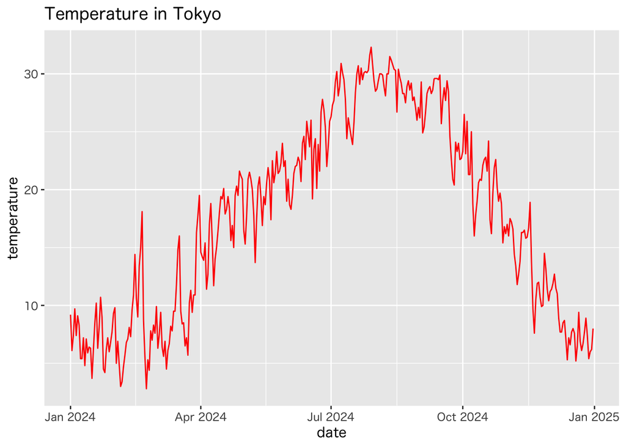

```r
tw_tsbl |>
    autoplot(temp, colour = "red") +
    labs(title = "Temperature in Tokyo",
         x = "date", y = "temperature")
```

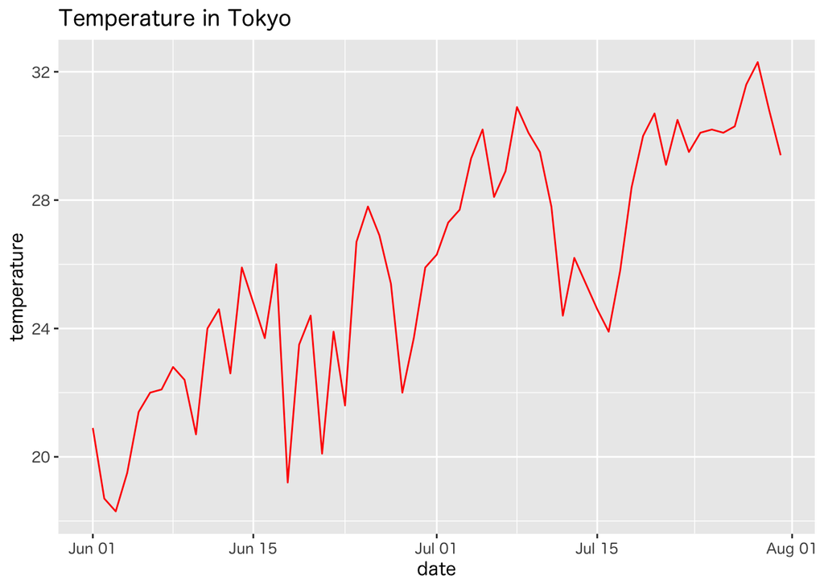

```r
tw_tsbl |> # 一部を切り出して視覚化する
    filter_index("2024-06-01" ~ "2024-07-31") |>
    autoplot(temp, colour = "red") +
    labs(title = "Temperature in Tokyo",
         x = "date", y = "temperature")
```

データの性質を確認する．

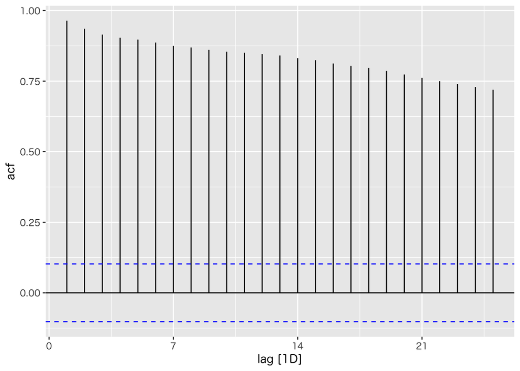

```r
tw_tsbl |> ACF(temp) |> # 自己相関
    autoplot()          # 減衰が遅いので差分をとった方が良さそう
```

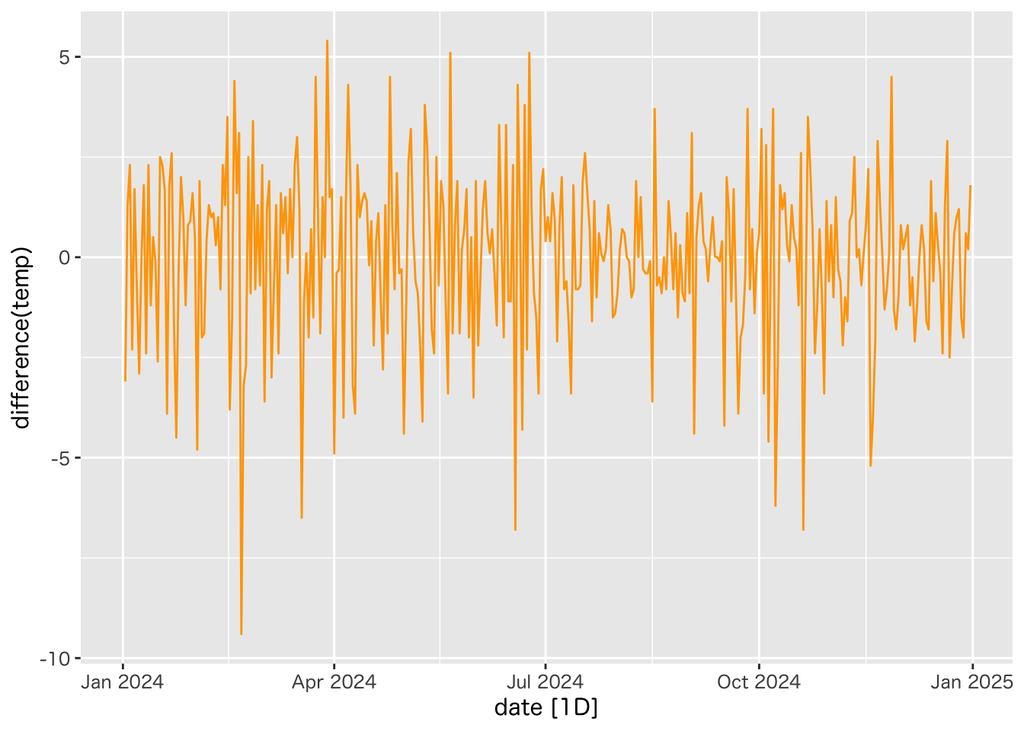

```r
tw_tsbl |>
    autoplot(difference(temp), colour = "orange")
```

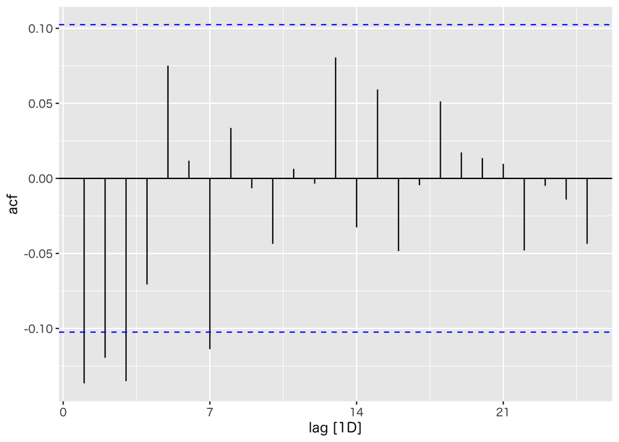

```r
tw_tsbl |> ACF(difference(temp)) |> # 階差系列の自己相関
    autoplot()
```

階差系列 (d=1) にARMAモデルをあてはめる．

```r
tw_fit <- tw_tsbl |>
    model(ARIMA(temp ~ pdq(d = 1) + PDQ(D = 0)))
report(tw_fit)       # 推定されたモデルの仕様を表示
```

```
Series: temp
Model: ARIMA(2,1,1)(0,0,1)[7]

Coefficients:
         ar1      ar2      ma1     sma1
      0.5619  -0.0929  -0.7883  -0.1168
s.e.  0.0745   0.0581   0.0566   0.0539

sigma^2 estimated as 4.094:  log likelihood=-773.39
AIC=1556.77   AICc=1556.94   BIC=1576.27
```

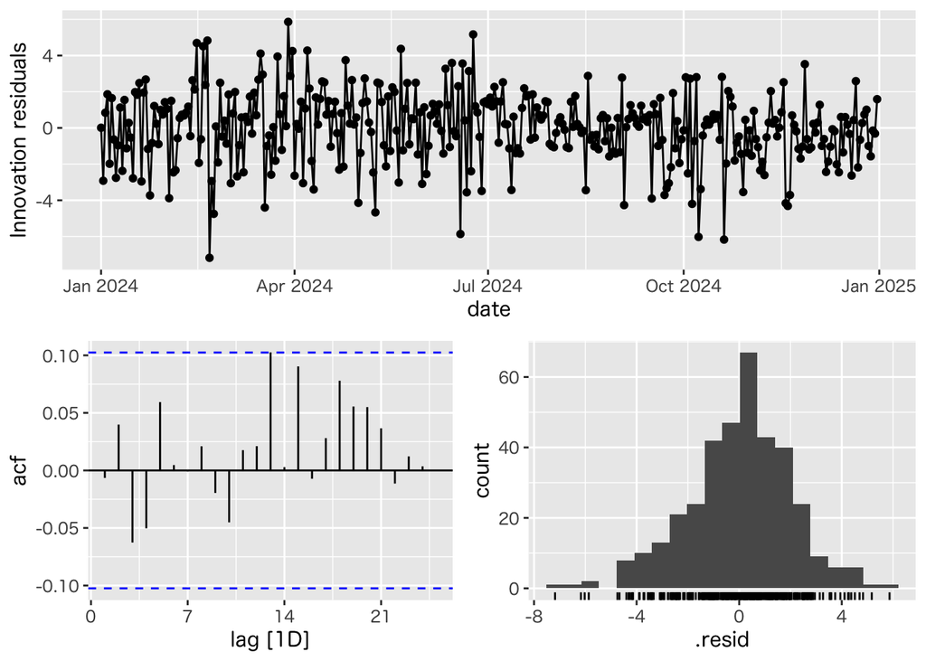

```r
tw_fit |>            # 残差の評価
    gg_tsresiduals() # そこそこあてはまりは良さそう
```

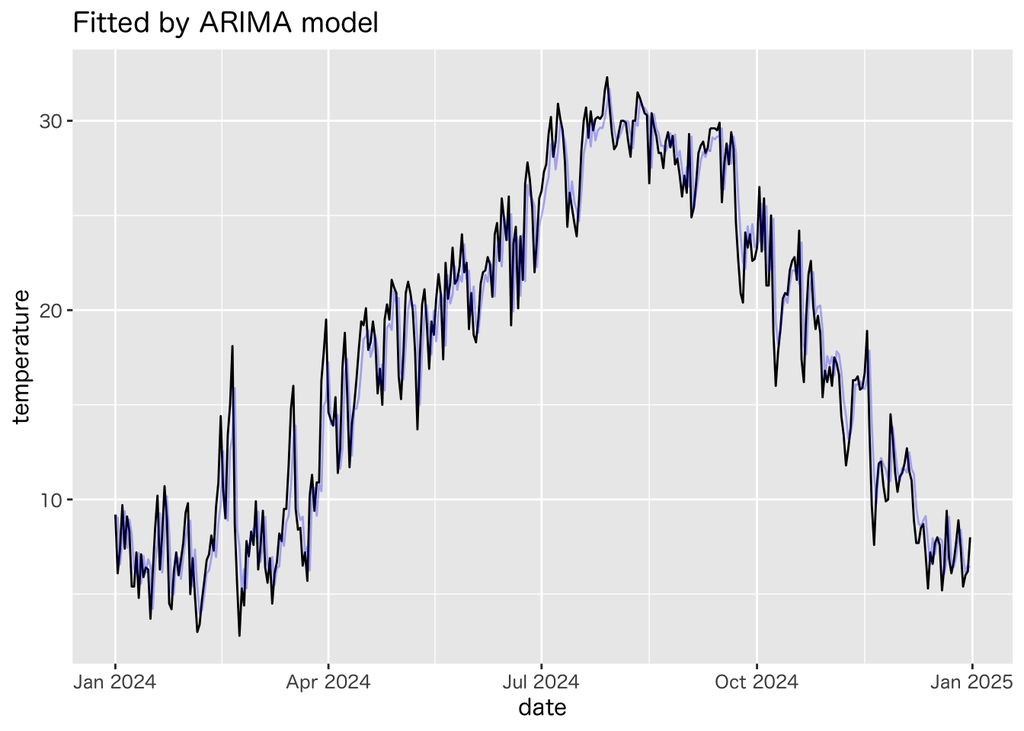

```r
tw_fit |>            # データとあてはめ値の比較
    augment() |>
    autoplot(temp) +
    geom_line(aes(y = .fitted), # y軸にあてはめ値を指定
              colour = "blue", alpha = 0.3) +
    labs(title = "Fitted by ARIMA model",
         x = "date", y = "temperature")
```

## 時系列の予測

推定されたモデルを用いて予測を行うには， 関数 `fable::forecast()** を用いる．

**Note時系列の予測**

```r
forecast(object, h, ...)
#' object: モデルの推定結果
#' h: h期先の予測
#' 詳細は `?fable::forecast.X` (Xはモデル名)を参照
```

使い方は以下のようになるが， 描画には関数 `fabletools::autoplot.fbl_ts()` が利用できる．

```r
as_tsibble(AirPassengers) |>
    model(ARIMA(log(value))) |>
    forecast(h = 36) |> autoplot(AirPassengers)
```

分解モデルの推定には関数 `fable::ETS()` を用いる．

**Note**

```r
ETS(formula, opt_crit = c("lik", "amse", "mse", "sigma", "mae"),
    nmse = 3, bounds = c("both", "usual", "admissible"),
    ic = c("aicc", "aic", "bic"), restrict = TRUE, ...)
#' formula: 時系列モデル
#' opt_crit: モデルの最適化の指標
#' ic: モデル選択のための情報量規準
#' その他詳細は '?fable::ETS' を参照
```

以下が推定の例である．

```r
as_tsibble(AirPassengers) |>
    model(ETS(value ~ season("M"))) |>
    components() |> autoplot()
```

### 問題

以下の問に答えなさい．

- COVID-19のデータを用いて分析・予測を行いなさい． https://covid19.mhlw.go.jp/public/opendata/newly_confirmed_cases_daily.csv
- `datasets::AirPassengers` データを用いて分析・予測を行いなさい．

### 解答例

#### 厚生労働省のCOVID-19の感染者数データ

以下は解析事例で紹介した内容となる．

データを取得する．

```r
cp_tbl <-
    read_csv("https://covid19.mhlw.go.jp/public/opendata/newly_confirmed_cases_daily.csv") |>
    select(1:2) |>
    set_names(c("date","patients")) |>
    mutate(date = as_date(date))
```

データを `tsibble` クラスに変換する．

```r
cp_tsbl <-
    cp_tbl |>
    as_tsibble(index = date)
```

データ(全国・全期間)を表示する．

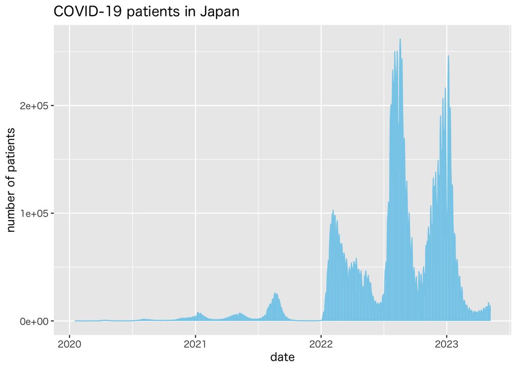

```r
cp_tsbl |>
    autoplot(patients, colour = "skyblue") +
    geom_col(fill = "skyblue") + # 塗り潰しを行う
    labs(title = "COVID-19 patients in Japan",
         x = "date",
         y = "number of patients")
```

第3波 (2020/9/15-2021/1/31) に着目する．

```r
cp_3rd_train <- # 訓練データ
    cp_tsbl |>
    filter_index("2020-09-15" ~ "2020-11-30")
cp_3rd_test <-  # 試験データ
    cp_tsbl |>
    filter_index("2020-12-01" ~ "2021-01-31")
```

データを表示する．

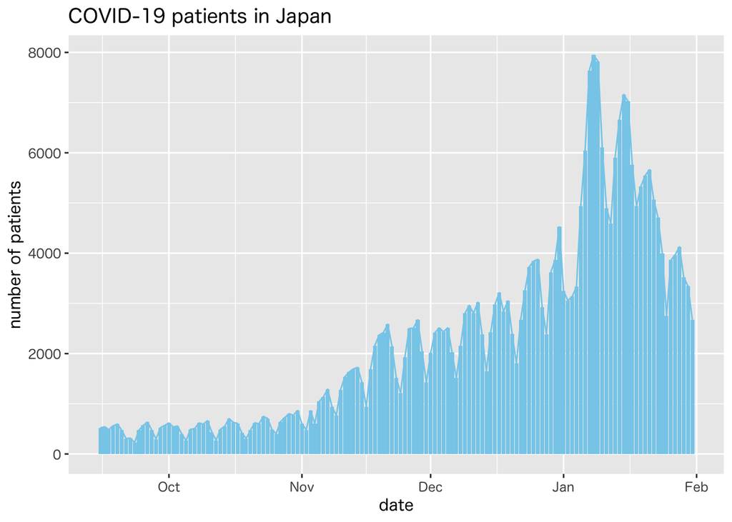

```r
bind_rows(cp_3rd_train,cp_3rd_test) |>
    autoplot(patients, colour = "skyblue") +
    geom_col(fill = "skyblue") + # 塗り潰しを行う
    labs(title = "COVID-19 patients in Japan",
         x = "date",
         y = "number of patients")
```

階差系列を描画する．

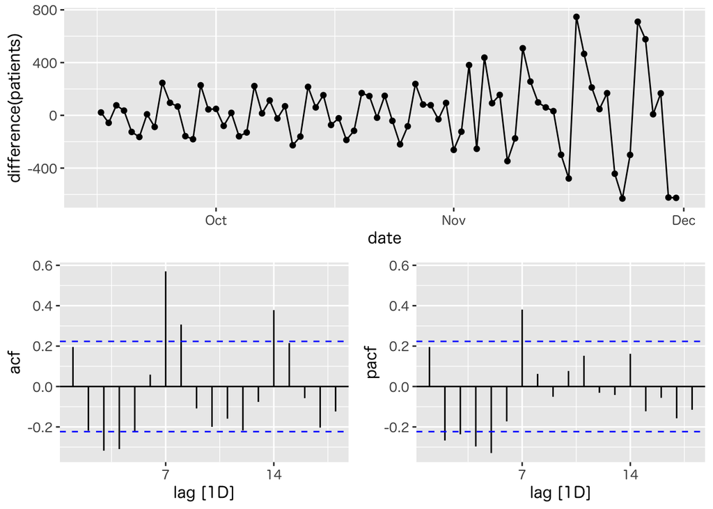

```r
cp_3rd_train |>
    gg_tsdisplay(difference(patients),
                 plot_type = "partial")
```

7日周期の影響があることがわかる．

対数変換をした階差系列を描画する．

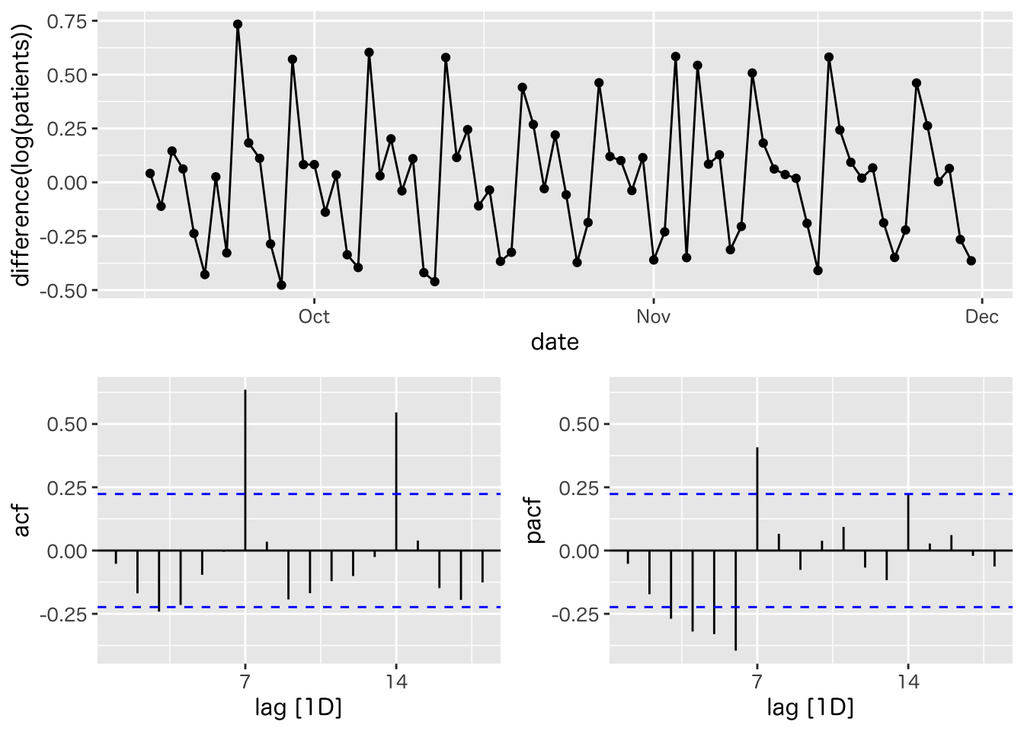

```r
cp_3rd_train |>
    gg_tsdisplay(difference(log(patients)),
                 plot_type = "partial")
```

やはり7日周期の影響があることがわかる．

7日の周期(季節成分)での階差系列を描画する．

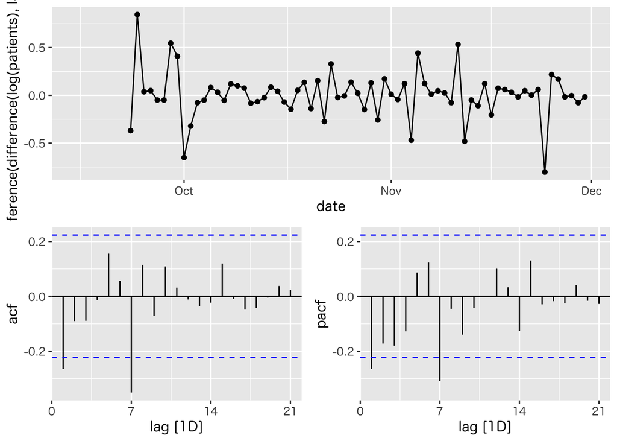

```r
cp_3rd_train |>
    gg_tsdisplay(difference(difference(log(patients), lag = 7)),
                 lag_max = 21,
                 plot_type = "partial")
```

7日の相関は負になっているので，季節階差は取らなくても良さそう．

以下では対数変換した系列に対してARIMAモデルをあてはめる．

```r
cp_3rd_arima <-
    cp_3rd_train |>
    model(ARIMA(log(patients) ~ PDQ(D = 0)))
```

推定結果を検討する．

```r
cp_3rd_arima |> report()
```

```
Series: patients
Model: ARIMA(1,1,1)(2,0,0)[7]
Transformation: log(patients)

Coefficients:
         ar1      ma1    sar1    sar2
      0.4493  -0.8309  0.3709  0.4232
s.e.  0.1635   0.0981  0.1212  0.1353

sigma^2 estimated as 0.03811:  log likelihood=15.04
AIC=-20.07   AICc=-19.21   BIC=-8.42
```

```r
cp_3rd_arima |> accuracy()
```

```
# A tibble: 1 × 10
  .model                  .type    ME  RMSE   MAE   MPE  MAPE  MASE RMSSE   ACF1
  <chr>                   <chr> <dbl> <dbl> <dbl> <dbl> <dbl> <dbl> <dbl>  <dbl>
1 ARIMA(log(patients) ~ … Trai…  20.9  193.  111. 0.400  13.4 0.521 0.616 0.0355
```

```r
cp_3rd_arima |> glance()
```

```
# A tibble: 1 × 8
  .model                      sigma2 log_lik   AIC  AICc   BIC ar_roots ma_roots
  <chr>                        <dbl>   <dbl> <dbl> <dbl> <dbl> <list>   <list>
1 ARIMA(log(patients) ~ PDQ(… 0.0381    15.0 -20.1 -19.2 -8.42 <cpl>    <cpl>
```

データとあてはめ値を表示する．

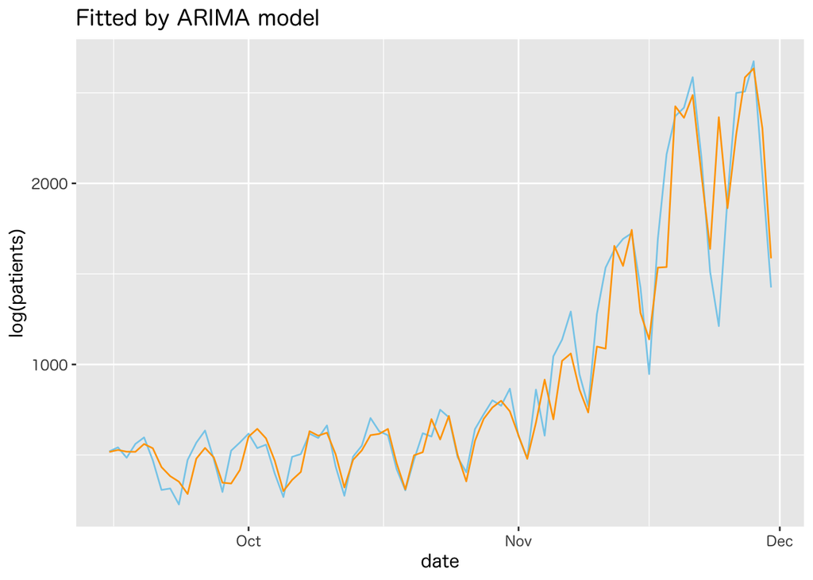

```r
cp_3rd_arima |>
    augment() |>
    autoplot(patients, colour = "skyblue") +
    geom_line(aes(y = .fitted), colour = "orange") +
    labs(title = "Fitted by ARIMA model",
         x = "date", y = "log(patients)")
```

残差の診断を行う．

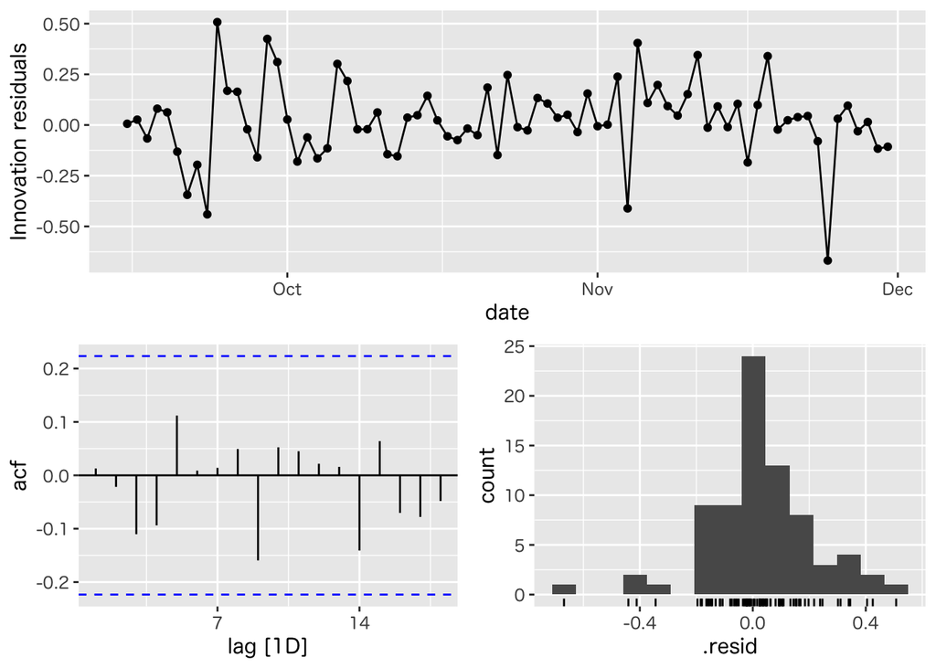

```r
cp_3rd_arima |> gg_tsresiduals()
```

残差の相関はだいぶ消えているので，そこそこ良いモデルといえそう．

後半を予測してみる．

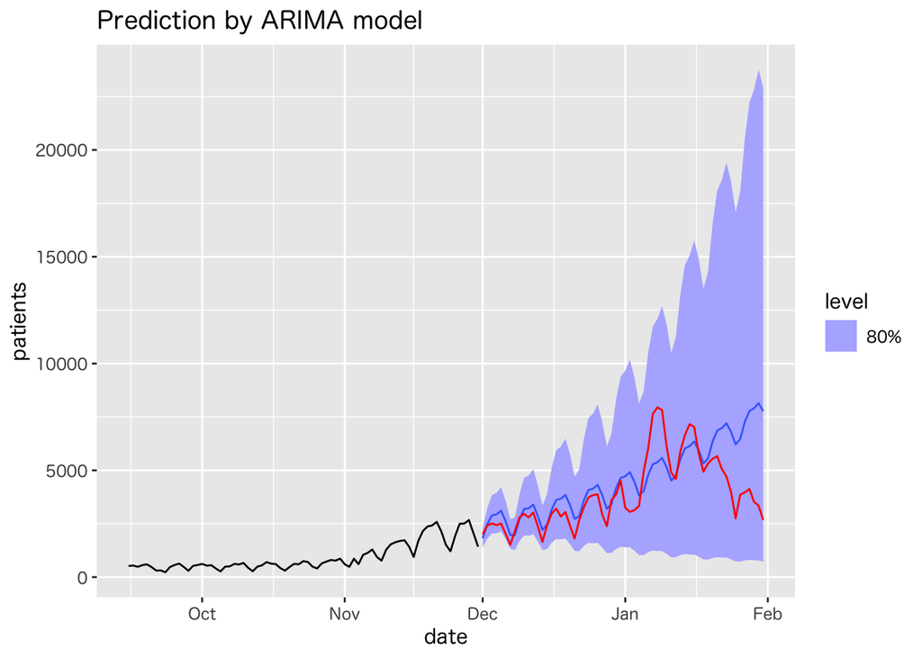

```r
cp_3rd_arima |>
    forecast(h = nrow(cp_3rd_test)) |>
    autoplot(cp_3rd_train, level = 80) +
    autolayer(cp_3rd_test, .vars = patients, colour = "red") +
    labs(title = "Prediction by ARIMA model")
```

感染が収まるまでの増加傾向を上手く推定できていることがわかる．

第8波 (2022/11/01-2023/1/31) に着目する．

```r
cp_8th_train <- # 訓練データ
    cp_tsbl |>
    filter_index("2022-11-01" ~ "2022-11-30")
cp_8th_test <-  # 試験データ
    cp_tsbl |>
    filter_index("2022-12-01" ~ "2023-01-31")
```

データの表示を行う．

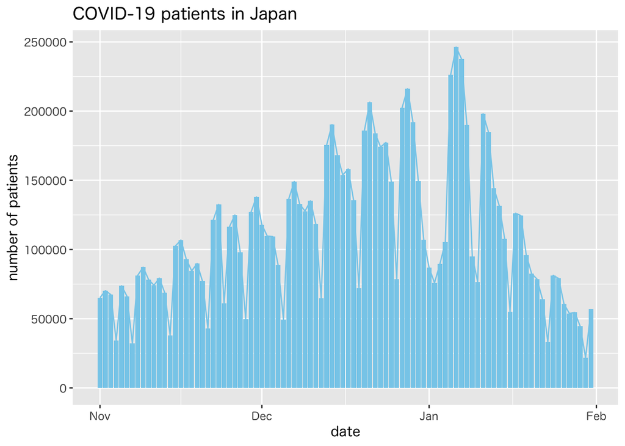

```r
bind_rows(cp_8th_train,cp_8th_test) |>
    autoplot(patients, colour = "skyblue") +
    geom_col(fill = "skyblue") + # 塗り潰しを行う
    labs(title = "COVID-19 patients in Japan",
         x = "date",
         y = "number of patients")
```

階差系列を描画する．

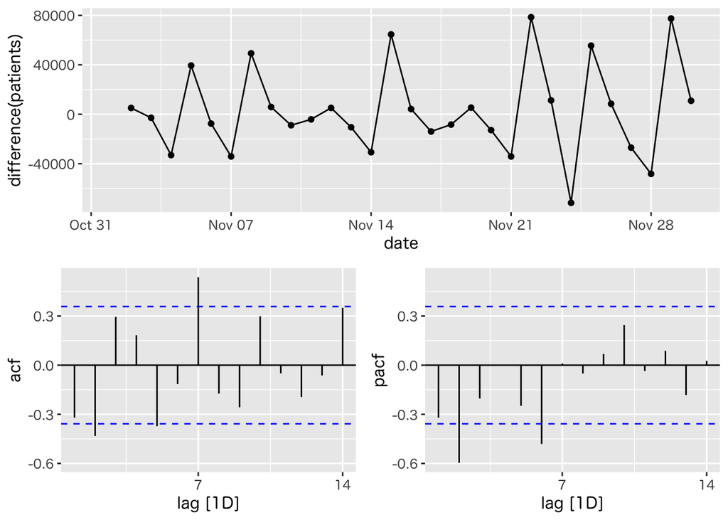

```r
cp_8th_train |>
    gg_tsdisplay(difference(patients),
                 plot_type = "partial")
```

対数変換をした階差系列を描画する．

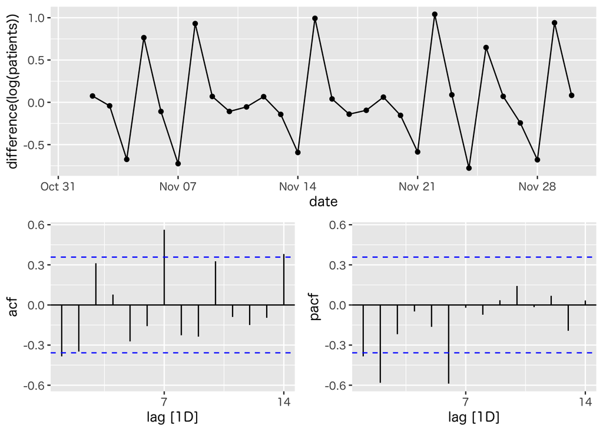

```r
cp_8th_train |>
    gg_tsdisplay(difference(log(patients)),
                 plot_type = "partial")
```

7日の周期(季節成分)での階差系列を描画する．

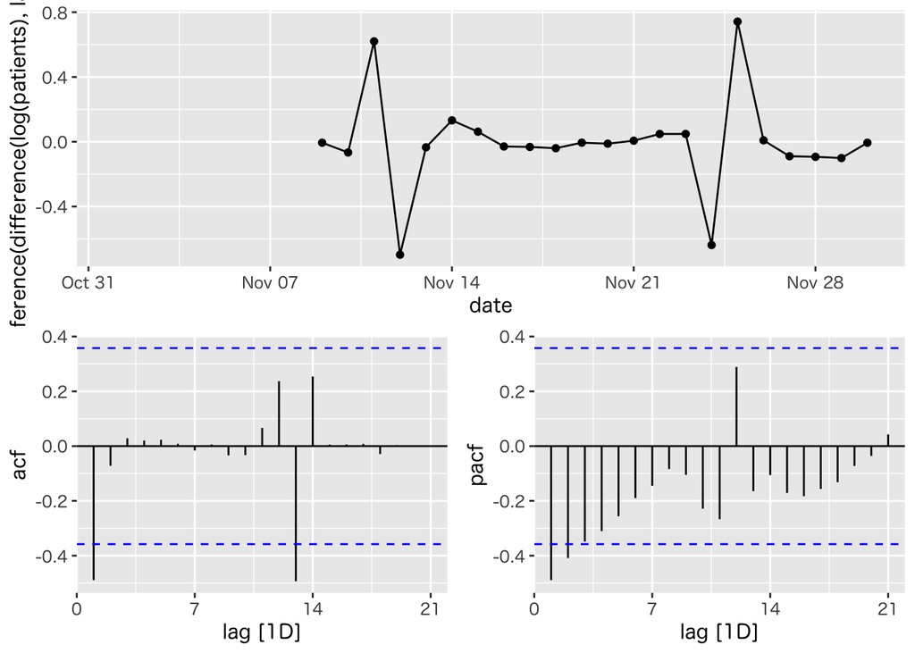

```r
cp_8th_train |>
    gg_tsdisplay(difference(difference(log(patients), lag = 7)),
                 lag_max = 21,
                 plot_type = "partial")
```

対数変換した系列に対してARIMAモデルをあてはめる．

```r
cp_8th_arima <-
    cp_8th_train |>
    model(ARIMA(log(patients) ~ PDQ(D = 0)))
```

推定結果を検討する．

```r
cp_8th_arima |> report()
```

```
Series: patients
Model: ARIMA(0,1,1)(1,0,0)[7]
Transformation: log(patients)

Coefficients:
          ma1    sar1
      -0.8737  0.8784
s.e.   0.0687  0.0680

sigma^2 estimated as 0.04256:  log likelihood=0.19
AIC=5.62   AICc=6.58   BIC=9.72
```

```r
cp_8th_arima |> accuracy()
```

```
# A tibble: 1 × 10
  .model               .type    ME   RMSE    MAE    MPE  MAPE  MASE RMSSE   ACF1
  <chr>                <chr> <dbl>  <dbl>  <dbl>  <dbl> <dbl> <dbl> <dbl>  <dbl>
1 ARIMA(log(patients)… Trai… 2081. 14315. 10219. -0.867  13.8 0.636 0.744 -0.147
```

```r
cp_8th_arima |> glance()
```

```
# A tibble: 1 × 8
  .model                      sigma2 log_lik   AIC  AICc   BIC ar_roots ma_roots
  <chr>                        <dbl>   <dbl> <dbl> <dbl> <dbl> <list>   <list>
1 ARIMA(log(patients) ~ PDQ(… 0.0426   0.192  5.62  6.58  9.72 <cpl>    <cpl>
```

データとあてはめ値を表示する．

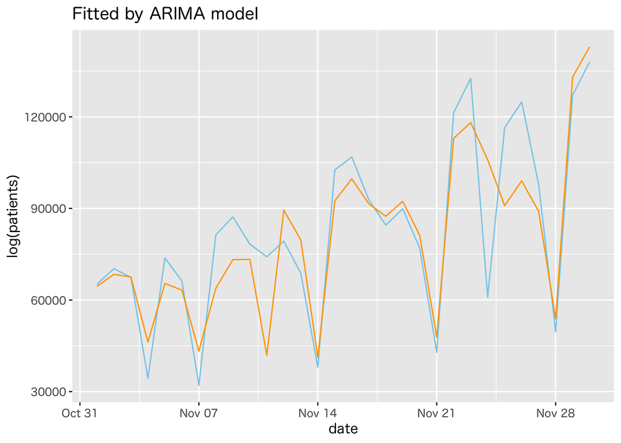

```r
cp_8th_arima |>
    augment() |>
    autoplot(patients, colour = "skyblue") +
    geom_line(aes(y = .fitted), colour = "orange") +
    labs(title = "Fitted by ARIMA model",
         x = "date", y = "log(patients)")
```

残差の診断を行う．

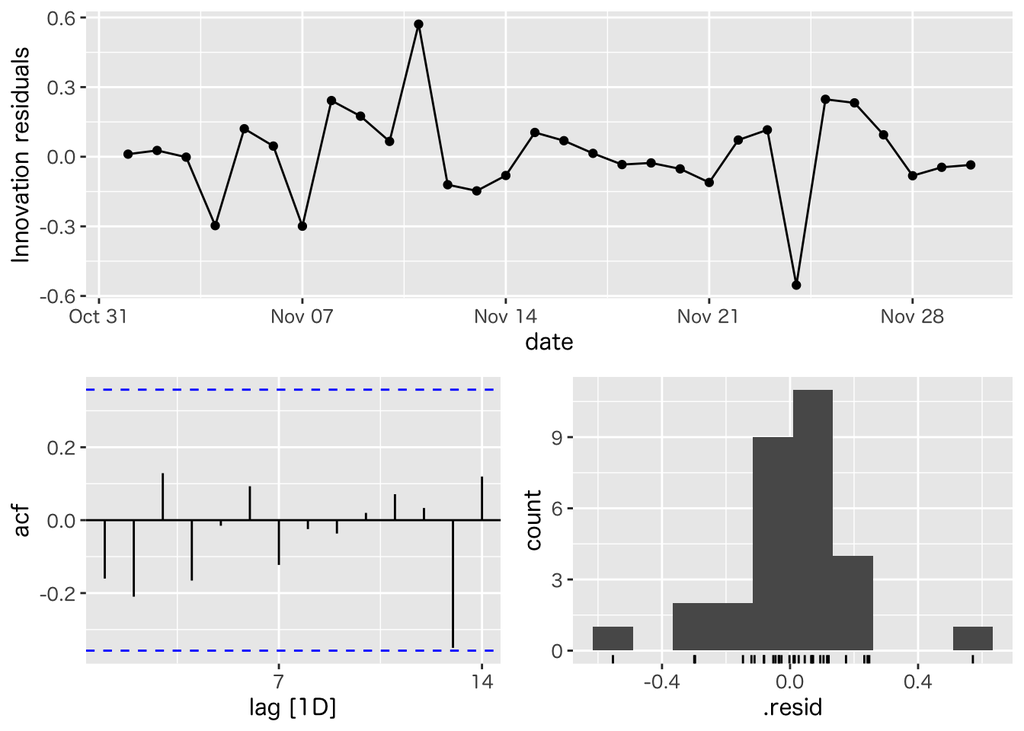

```r
cp_8th_arima |> gg_tsresiduals()
```

後半を予測する．

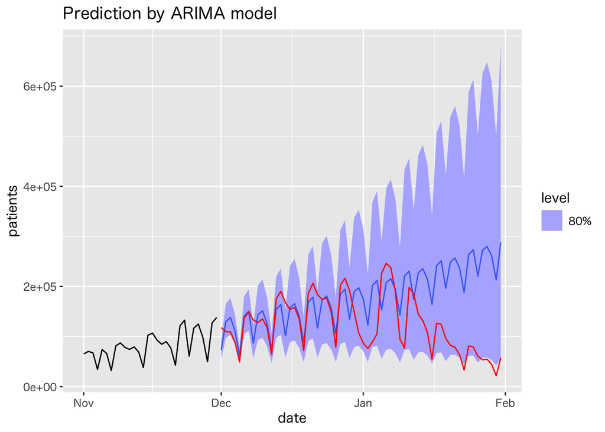

```r
cp_8th_arima |>
    forecast(h = nrow(cp_8th_test)) |>
    autoplot(cp_8th_train, level = 80) +
    autolayer(cp_8th_test, .vars = patients, colour = "red") +
    labs(title = "Prediction by ARIMA model")
```

`package::fable` に実装されているいくつかの方法で予測してみる．

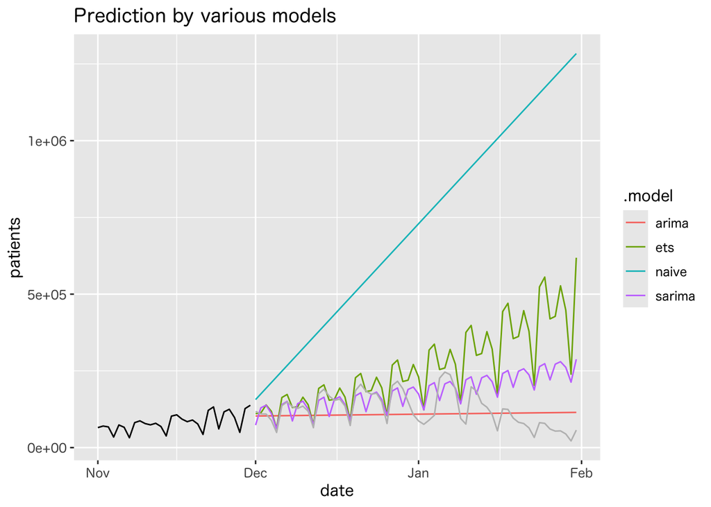

```r
cp_8th_models <-
    cp_8th_train |>
    model( # 自動推定
        naive  = NAIVE(log(patients)),  # random walk model
        arima  = ARIMA(log(patients) ~ pdq() + PDQ(0,0,0)),
        sarima = ARIMA(log(patients) ~ pdq() + PDQ(D = 0)),
        ets    = ETS(log(patients)),    # exponential smoothing
        )
cp_8th_models |>
    forecast(h = nrow(cp_8th_test)) |>
    autoplot(cp_8th_train, level = NULL) +
    autolayer(cp_8th_test, .vars = patients, colour = "gray") +
    labs(title = "Prediction by various models")
```